# TP11_ML_HCB

## [ ML ] Data_Salaries 예측

**[ data ] : 조사연도, 숙련도, 고용형태, 직업군, 급여, 통화, 직원 거주지, 원격업무 비중, 회사 위치, 회사 크기**  
**[ target ] : 달러화한 급여**

**=> data 중 조사연도, 급여 제외 모두 입력**

### 회귀 : 입력하는 data 따라, 급여는 얼마가 될 것인가

### 사용 모델 : 의사결정트리 -> 랜덤포레스트, 그래디언트부스팅, 히스트그래디언팅

### 과정 :

### 데이터 로딩/확인 - 전처리 - 분리 - all_estimators로 모델 고르기

### 선택 모델 => 객체생성 - 훈련 - CV+파라미터조절=그리드서치 - 평가 - 예측

### [ 모듈 로딩 ]

```python
import pandas as pd
import numpy as np
import matplotlib.pyplot as plt
import warnings
warnings.filterwarnings(action='ignore')   # 경고무시
import platform
from sklearn.model_selection import GridSearchCV

# 글씨체
if platform.system() == 'Windows':
    plt.rc('font', family='Malgun Gothic')
else:
    plt.rc('font', family='AppleGothic')

# 그래프 음수 가능
plt.rcParams['axes.unicode_minus'] = False
```

### [ 데이터 불러오기 ]

```python
# 데이터 읽어오기
df = pd.read_csv('./data/ds_salaries_ori.csv')
df.head()
```

|  | work_year | experience_level | employment_type | job_title | salary | salary_currency | employee_residence | remote_ratio | company_location | company_size | salary_in_usd |
| --- | --- | --- | --- | --- | --- | --- | --- | --- | --- | --- | --- |
| 0 | 2020 | MI | FT | Scientist | 70000 | EUR | DE | 0 | DE | L | 79833 |
| 1 | 2020 | SE | FT | Scientist | 260000 | USD | JP | 0 | JP | S | 260000 |
| 2 | 2020 | SE | FT | Engineer | 85000 | GBP | GB | 50 | GB | M | 109024 |
| 3 | 2020 | MI | FT | Analyst | 20000 | USD | HN | 0 | HN | S | 20000 |
| 4 | 2020 | SE | FT | Engineer | 150000 | USD | US | 50 | US | L | 150000 |

```python
# 데이터 확인
df.info()
```

```
<class 'pandas.core.frame.DataFrame'>
RangeIndex: 606 entries, 0 to 605
Data columns (total 11 columns):
 #   Column              Non-Null Count  Dtype
---  ------              --------------  -----
 0   work_year           606 non-null    int64
 1   experience_level    606 non-null    object
 2   employment_type     606 non-null    object
 3   job_title           606 non-null    object
 4   salary              606 non-null    int64
 5   salary_currency     606 non-null    object
 6   employee_residence  606 non-null    object
 7   remote_ratio        606 non-null    int64
 8   company_location    606 non-null    object
 9   company_size        606 non-null    object
 10  salary_in_usd       606 non-null    int64
dtypes: int64(4), object(7)
memory usage: 52.2+ KB
```

```python
# 결측치 개수 확인
df.isnull().sum()
```

```
work_year             0
experience_level      0
employment_type       0
job_title             0
salary                0
salary_currency       0
employee_residence    0
remote_ratio          0
company_location      0
company_size          0
salary_in_usd         0
dtype: int64
```

### [ 전처리 ]

미리 엑셀로 'job_title'의 직업들을 1차적으로 수정한 상태 (53가지 -> 8가지)

ex)  
'Machine Learning Developer',  
'Applied Machine Learning Scientist', 'Data Analytics Manager',  
'Data Specialist', 'Data Architect','BI Data Analyst','Research Scientist', ...

=> Analyst, Architect, Consultant, Developer, Engineer, Manager, Scientist, Data

```python
df['job_title'].unique()
```

```
array(['Scientist', 'Engineer', 'Analyst', 'Consultant', 'Manager',
       'Data', 'Developer', 'Architect'], dtype=object)
```

'salary'까지 넣었다가 score가 좋았는데,

생각해보니 타겟인 'salary_in_usd'를 us달러 비율로 바꾸기 전의 값이었기 때문에

특성 중요도도 높고, 모델 자체의 score가 좋게 나올 수 밖에 없었음을 깨닫게 됨

=> 타겟값을 그대로 넣어버린셈. 차후에 해당 피처 삭제

```python
# 불필요 피처 삭제
df.drop(['work_year','salary'], axis=1, inplace=True)
# salary는 salary_in_usd와 비슷한 피처라 삭제
# employee_residence는 company_location와 비슷
```

```python
df.columns
```

```
Index(['experience_level', 'employment_type', 'job_title', 'salary_currency',
       'employee_residence', 'remote_ratio', 'company_location',
       'company_size', 'salary_in_usd'],
      dtype='object')
```

### One-Hot Encoding

처음엔 했다가,  
타겟을 제외한 모든 피처들이 범주형, 특히 'job_title' 피처는 1차적으로 묶어주었음에도 8개  
원-핫 코딩을 하면 너무 많은 추가적인 피처들이 생김

컬럼이 너무 많아지면?  
각 특성의 범주에 들어가는 변수들이 모두 새로운 특성이 되므로 범주의 종류가 많아질수록 전체 데이터의 특성이 엄청나게 늘어남  
(이렇게 많아지는걸 high cardinality라고 말함) 이럴경우 원핫인코딩이 좋지 않음

### LabelEncoder

```python
from sklearn.preprocessing import LabelEncoder
la = LabelEncoder()

feature = ['experience_level', 'employment_type', 'job_title',
       'salary_currency', 'employee_residence', 'remote_ratio',
       'company_location', 'company_size']

for i in feature:
    la.fit(df[i])
    df[i] = la.transform(df[i])
```

```python
df
```

|  | experience_level | employment_type | job_title | salary_currency | employee_residence | remote_ratio | company_location | company_size | salary_in_usd |
| --- | --- | --- | --- | --- | --- | --- | --- | --- | --- |
| 0 | 2 | 2 | 7 | 7 | 14 | 0 | 12 | 0 | 79833 |
| 1 | 3 | 2 | 7 | 16 | 32 | 0 | 29 | 2 | 260000 |
| 2 | 3 | 2 | 5 | 8 | 20 | 1 | 18 | 1 | 109024 |
| 3 | 2 | 2 | 0 | 16 | 23 | 0 | 20 | 2 | 20000 |
| 4 | 3 | 2 | 5 | 16 | 55 | 1 | 48 | 0 | 150000 |
| ... | ... | ... | ... | ... | ... | ... | ... | ... | ... |
| 601 | 3 | 2 | 5 | 16 | 55 | 2 | 48 | 1 | 154000 |
| 602 | 3 | 2 | 5 | 16 | 55 | 2 | 48 | 1 | 126000 |
| 603 | 3 | 2 | 0 | 16 | 55 | 0 | 48 | 1 | 129000 |
| 604 | 3 | 2 | 0 | 16 | 55 | 2 | 48 | 1 | 150000 |
| 605 | 2 | 2 | 7 | 16 | 27 | 2 | 48 | 0 | 200000 |

606 rows × 9 columns

### [ 학습 & 테스트 데이터 분리 ]

```python
df
```

|  | experience_level | employment_type | job_title | salary_currency | employee_residence | remote_ratio | company_location | company_size | salary_in_usd |
| --- | --- | --- | --- | --- | --- | --- | --- | --- | --- |
| 0 | 2 | 2 | 7 | 7 | 14 | 0 | 12 | 0 | 79833 |
| 1 | 3 | 2 | 7 | 16 | 32 | 0 | 29 | 2 | 260000 |
| 2 | 3 | 2 | 5 | 8 | 20 | 1 | 18 | 1 | 109024 |
| 3 | 2 | 2 | 0 | 16 | 23 | 0 | 20 | 2 | 20000 |
| 4 | 3 | 2 | 5 | 16 | 55 | 1 | 48 | 0 | 150000 |
| ... | ... | ... | ... | ... | ... | ... | ... | ... | ... |
| 601 | 3 | 2 | 5 | 16 | 55 | 2 | 48 | 1 | 154000 |
| 602 | 3 | 2 | 5 | 16 | 55 | 2 | 48 | 1 | 126000 |
| 603 | 3 | 2 | 0 | 16 | 55 | 0 | 48 | 1 | 129000 |
| 604 | 3 | 2 | 0 | 16 | 55 | 2 | 48 | 1 | 150000 |
| 605 | 2 | 2 | 7 | 16 | 27 | 2 | 48 | 0 | 200000 |

606 rows × 9 columns

```python
# NumPy 배열 추출
X = df.iloc[:, :-1].values
y = df['salary_in_usd'].values
print('X.shape: {},  y.shape: {}'.format(X.shape, y.shape))
```

```
X.shape: (606, 8),  y.shape: (606,)
```

```python
from sklearn.model_selection import train_test_split

X_train, X_test, y_train, y_test = train_test_split(X, y)
# 데이터가 적어서 test자료를 25%, 15%, 10% 해보았는데, 기본값이 제일 나았음
# stratify 파라미터는 회귀보다 분류에서 쓴다고 함 (like stratifiedKFold)
```

```python
train_test_split(X, y)
```

[output not shown]

[output cut: 76 more lines]

### [ all_estimators로 모델 고르기 ]

```python
# 필터 타입에 해당하는 sklearn에 존재하는 모든 모델 이름과 객체 리스트로 반환
from sklearn.utils import all_estimators
models = all_estimators(type_filter = 'regressor')

# 각 모델들 훈련시키고 정확도 추출
scores = []
for name, model in models:
    try:
        # 모델 객체 생성
        md = model()
        # 학습
        md.fit(X_train, y_train)
        # 평가
        result = md.score(X_test, y_test)

        scores.append((name, np.round(result,3)))
    except:
        pass
```

```python
scores

# 'HistGradientBoostingRegressor', 0.499
# 'GradientBoostingRegressor', 0.466
# 'RandomForestRegressor', 0.482
```

```
[('ARDRegression', 0.19),
 ('AdaBoostRegressor', 0.14),
 ('BaggingRegressor', 0.381),
 ('BayesianRidge', 0.196),
 ('CCA', -0.175),
 ('DecisionTreeRegressor', 0.302),
 ('DummyRegressor', -0.02),
 ('ElasticNet', 0.192),
 ('ElasticNetCV', 0.105),
 ('ExtraTreeRegressor', 0.187),
 ('ExtraTreesRegressor', 0.34),
 ('GammaRegressor', 0.121),
 ('GaussianProcessRegressor', -0.044),
 ('GradientBoostingRegressor', 0.432),
 ('HistGradientBoostingRegressor', 0.372),
 ('HuberRegressor', 0.187),
 ('KNeighborsRegressor', 0.187),
 ('KernelRidge', 0.205),
 ('Lars', 0.192),
 ('LarsCV', 0.181),
 ('Lasso', 0.192),
 ('LassoCV', 0.196),
 ('LassoLars', 0.192),
 ('LassoLarsCV', 0.198),
 ('LassoLarsIC', 0.199),
 ('LinearRegression', 0.192),
 ('LinearSVR', 0.0),
 ('MLPRegressor', -2.452),
 ('NuSVR', -0.043),
 ('OrthogonalMatchingPursuit', 0.115),
 ('OrthogonalMatchingPursuitCV', 0.189),
 ('PLSCanonical', -1.159),
 ('PLSRegression', 0.198),
 ('PassiveAggressiveRegressor', 0.157),
 ('PoissonRegressor', 0.195),
 ('QuantileRegressor', 0.064),
 ('RANSACRegressor', -4.484),
 ('RadiusNeighborsRegressor', -4.0137325022813847e+27),
 ('RandomForestRegressor', 0.387),
 ('Ridge', 0.192),
 ('RidgeCV', 0.194),
 ('SGDRegressor', -198507873162070.78),
 ('SVR', -0.077),
 ('TheilSenRegressor', -0.215),
 ('TransformedTargetRegressor', 0.192),
 ('TweedieRegressor', 0.183)]
```

#### 원-핫 인코딩(피처수), train-test 분리할 때 test_size, 피처간 관계파악 -> 피처 조절(특성 공학), 모델의 선정, 하이퍼 파라미터 조절

### [ 의사결정나무 ]

```python
from sklearn.tree import DecisionTreeRegressor
r_model = DecisionTreeRegressor()
r_model
```

```
DecisionTreeRegressor()
```

```python
r_model.fit(X_train, y_train)
print("훈  련 세트 : {:.3f}".format(r_model.score(X_train, y_train)))
print("테스트 세트 : {:.3f}".format(r_model.score(X_test, y_test)))
```

```
훈  련 세트 : 0.747
테스트 세트 : 0.386
```

```python
# 피처이름 미리 정해주기
feature_names = df.columns[:9]
feature_names
```

```
Index(['experience_level', 'employment_type', 'job_title', 'salary_currency',
       'employee_residence', 'remote_ratio', 'company_location',
       'company_size', 'salary_in_usd'],
      dtype='object')
```

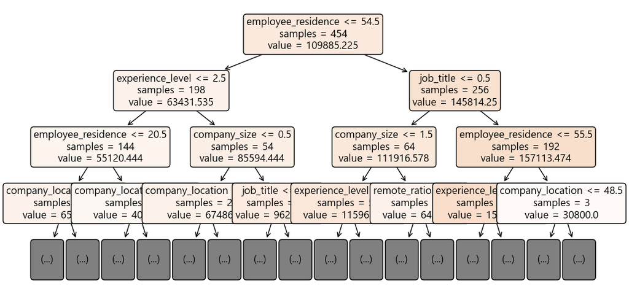

```python
from sklearn.tree import plot_tree
plt.figure(figsize=(12,6))
plot_tree(r_model, max_depth=3, filled=True, feature_names=feature_names,
          impurity=False, rounded=True, fontsize=12)
plt.show()
```

```python
# 특성 중요도
print('특성 중요도:\n', r_model.feature_importances_)
```

```
특성 중요도:
 [0.13349293 0.01299513 0.16640131 0.01531166 0.52920199 0.04284214
 0.03172972 0.06802511]
```

```python
X.shape[1]
```

```
8
```

```python
np.arange(8)
```

```
array([0, 1, 2, 3, 4, 5, 6, 7])
```

```python
[0] * 8
```

```
[0, 0, 0, 0, 0, 0, 0, 0]
```

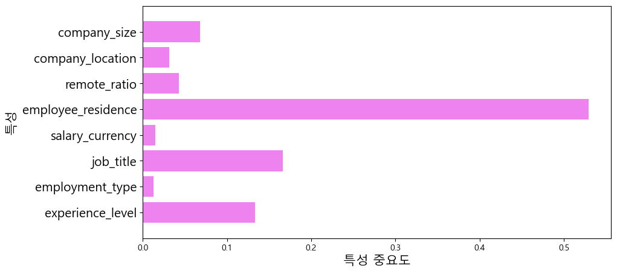

```python
def plot_feature_importances_cancer(model):
    n_features = X.shape[1]
    plt.figure(figsize=(10,5))
    plt.barh(np.arange(n_features), model.feature_importances_, align='center', color='violet')
    plt.yticks(np.arange(n_features), feature, fontsize=15)
    plt.xlabel('특성 중요도', fontsize=15)
    plt.ylabel('특성', fontsize=15)
    plt.ylim(-1, n_features)
    plt.show()

plot_feature_importances_cancer(r_model)
```

### [ 랜덤 포레스트 ]

```python
from sklearn.ensemble import RandomForestRegressor
regr = RandomForestRegressor(max_depth=5, max_features=0.7, max_samples=0.9,
                      n_estimators=50, oob_score=True)
regr = regr.fit(X_train, y_train)
regr
```

```
RandomForestRegressor(max_depth=5, max_features=0.7, max_samples=0.9,
                      n_estimators=50, oob_score=True)
```

```python
# 특성 중요도
print('특성 중요도:\n', regr.feature_importances_)
```

```
특성 중요도:
 [0.1362758  0.00475678 0.09138455 0.0591151  0.45496245 0.01774645
 0.17000082 0.06575804]
```

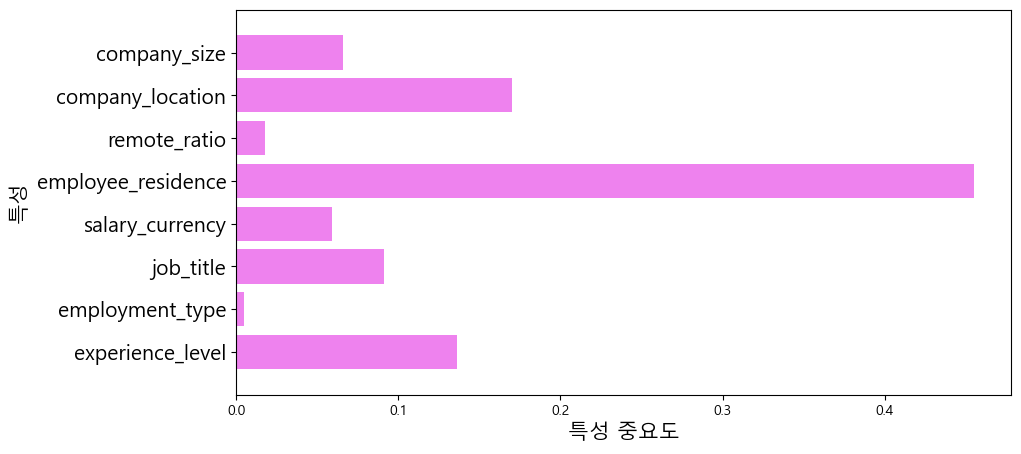

```python
plot_feature_importances_cancer(regr)
```

### 교차검증 (CV)

```python
from sklearn.model_selection import cross_val_score, cross_validate # 각 활용처 알아보고 cross_val_predict,
result = cross_val_score(regr, X, y, cv=10)
```

```python
allResult = cross_validate(regr, X, y,
                           return_train_score=True,
                           cv=10)
```

```python
resultDF1 = pd.DataFrame(allResult)
resultDF1[['test_score', 'train_score']]
```

|  | test_score | train_score |
| --- | --- | --- |
| 0 | 0.347169 | 0.569286 |
| 1 | 0.403607 | 0.580264 |
| 2 | 0.399517 | 0.566526 |
| 3 | 0.561321 | 0.532175 |
| 4 | 0.182915 | 0.565525 |
| 5 | 0.452917 | 0.562683 |
| 6 | 0.457444 | 0.569695 |
| 7 | 0.537668 | 0.549894 |
| 8 | 0.425154 | 0.556809 |
| 9 | 0.221958 | 0.571020 |

### KFold

```python
# Splitter 객체 생성 - KFold()
from sklearn.model_selection import KFold

kSplitter = KFold(n_splits=10, shuffle=True)
```

```python
allResult1 = cross_validate(regr, X, y,
                           return_train_score=True,
                           return_estimator=True,
                           cv=kSplitter)

resultDF1 = pd.DataFrame(allResult1)
resultDF1[['test_score', 'train_score']]
```

|  | test_score | train_score |
| --- | --- | --- |
| 0 | 0.388167 | 0.568005 |
| 1 | 0.386820 | 0.566569 |
| 2 | 0.443634 | 0.557626 |
| 3 | 0.539054 | 0.562198 |
| 4 | 0.298983 | 0.595747 |
| 5 | 0.243852 | 0.565197 |
| 6 | 0.456483 | 0.544785 |
| 7 | 0.551362 | 0.557470 |
| 8 | 0.617813 | 0.558202 |
| 9 | 0.369683 | 0.563892 |

### 하이퍼파라미터 조절

```python
# for문으로 파라미터 하나씩 높은 것 찾아나가기 (여러 파라미터 함께 쓰였을 경우, 달라질 것 생각 못함)
for i in range(10,201,10):
  r_model = RandomForestRegressor(n_estimators = i)
  r_model.fit(X_train, y_train)

  relation_square = r_model.score(X_train, y_train)
  print('결정계수 : ', round(relation_square,3))
```

```
결정계수 :  0.713
결정계수 :  0.715
결정계수 :  0.706
결정계수 :  0.709
결정계수 :  0.713
결정계수 :  0.715
결정계수 :  0.714
결정계수 :  0.714
결정계수 :  0.713
결정계수 :  0.714
결정계수 :  0.714
결정계수 :  0.714
결정계수 :  0.714
결정계수 :  0.714
결정계수 :  0.713
결정계수 :  0.714
결정계수 :  0.714
결정계수 :  0.712
결정계수 :  0.714
결정계수 :  0.712
```

### GridSearchCV

```python
parameters_r = {'n_estimators': [50, 100, 150, 200, 400],
                  'max_depth'    :  [5, 10, 15, 20],
                  'max_samples' : [0.2, 0.4, 0.7, 0.8, 0.9, 1.0],
                  'max_features'    : [0.2, 0.4, 0.7, 0.8, 0.9, 1.0]
                 }
```

```python
grid_reg = GridSearchCV(estimator=regr, param_grid = parameters_r, cv = 2, n_jobs=-1)
grid_reg.fit(X_train, y_train)
```

```
GridSearchCV(cv=2,
             estimator=RandomForestRegressor(max_depth=5, max_features=0.7,
                                             max_samples=0.9, n_estimators=50,
                                             oob_score=True),
             n_jobs=-1,
             param_grid={'max_depth': [5, 10, 15, 20],
                         'max_features': [0.2, 0.4, 0.7, 0.8, 0.9, 1.0],
                         'max_samples': [0.2, 0.4, 0.7, 0.8, 0.9, 1.0],
                         'n_estimators': [50, 100, 150, 200, 400]})
```

```python
print(" Result " )
print("\n [Best estimator] :\n",grid_reg.best_estimator_)
print("\n [Best score] :\n",grid_reg.best_score_)
print("\n [Best parameters] :\n",grid_reg.best_params_)
```

```
 Result

 [Best estimator] :
 RandomForestRegressor(max_depth=20, max_features=0.7, max_samples=0.2,
                      oob_score=True)

 [Best score] :
 0.39665443939278655

 [Best parameters] :
 {'max_depth': 20, 'max_features': 0.7, 'max_samples': 0.2, 'n_estimators': 100}
```

### 모델 평가

```python
# regr.score(X_train, y_train)
print("훈  련 세트 : {:.3f}".format(regr.score(X_train, y_train)))
print("테스트 세트 : {:.3f}".format(regr.score(X_test, y_test)))
print('\n(파라미터 변경전 : n_jobs=-1,oob_score=True)\n훈  련 세트 : 0.715\n테스트 세트 : 0.496')
```

```
훈  련 세트 : 0.575
테스트 세트 : 0.367

(파라미터 변경전 : n_jobs=-1,oob_score=True)
훈  련 세트 : 0.715
테스트 세트 : 0.496
```

### 예측값과 실제값 비교

```python
X_test = X_test.tolist()
y_test = y_test.tolist()
```

```python
predicted = regr.predict(X_test)
predicted = predicted.tolist()
```

```python
pred_df = pd.DataFrame({ 'test값':y_test, 'predict값':predicted })
```

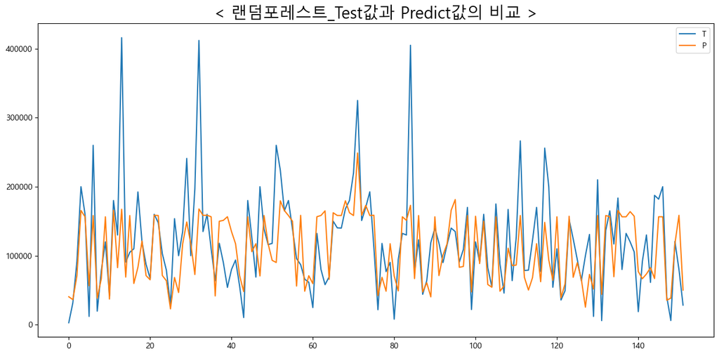

```python
plt.figure(figsize=(15,7))
plt.title('< 랜덤포레스트_Test값과 Predict값의 비교 >', fontsize=20)
plt.plot(pred_df)
plt.legend('TP')
plt.show()
```

### [ 그래디언트부스팅 ]

```python
from sklearn.ensemble import GradientBoostingRegressor
reg = GradientBoostingRegressor(alpha=0.1, learning_rate=0.03, max_depth=4, subsample=0.9)
reg.fit(X_train, y_train)
```

```
GradientBoostingRegressor(alpha=0.1, learning_rate=0.03, max_depth=4,
                          subsample=0.9)
```

### 교차검증 (CV)

```python
from sklearn.model_selection import cross_val_score, cross_validate # 각 활용처 알아보고 cross_val_predict,
result = cross_val_score(reg, X, y, cv=10)
```

```python
allResult = cross_validate(reg, X, y,
                           return_train_score=True,
                           cv=10)
```

```python
resultDF1 = pd.DataFrame(allResult)
resultDF1[['test_score', 'train_score']]
```

|  | test_score | train_score |
| --- | --- | --- |
| 0 | 0.365043 | 0.619849 |
| 1 | 0.397416 | 0.634953 |
| 2 | 0.459998 | 0.610164 |
| 3 | 0.613401 | 0.581567 |
| 4 | 0.230651 | 0.614918 |
| 5 | 0.378073 | 0.608860 |
| 6 | 0.470513 | 0.610474 |
| 7 | 0.566868 | 0.604090 |
| 8 | 0.441582 | 0.602814 |
| 9 | 0.222201 | 0.612249 |

### KFold

```python
# Splitter 객체 생성 - KFold()
from sklearn.model_selection import KFold

kSplitter = KFold(n_splits=10, shuffle=True)
```

```python
allResult1 = cross_validate(reg, X, y,
                           return_train_score=True,
                           return_estimator=True,
                           cv=kSplitter)

resultDF1 = pd.DataFrame(allResult1)
resultDF1[['test_score', 'train_score']]
```

|  | test_score | train_score |
| --- | --- | --- |
| 0 | 0.540542 | 0.603000 |
| 1 | 0.527425 | 0.605170 |
| 2 | 0.459830 | 0.600791 |
| 3 | 0.652104 | 0.599958 |
| 4 | 0.220976 | 0.620170 |
| 5 | 0.387865 | 0.620371 |
| 6 | 0.477880 | 0.608447 |
| 7 | 0.620278 | 0.597676 |
| 8 | 0.335577 | 0.628203 |
| 9 | 0.389230 | 0.613775 |

### 하이퍼파라미터 조절

### GridSearchCV

```python
parameters = {'learning_rate': [0.01,0.02,0.03,0.04],
              'alpha'    : [0.1, 0.3, 0.5, 0.7],
              'n_estimators' : [100,500,1000, 1500],
              'max_depth'    : [4,6,8,10],
               'subsample'   : [0.3, 0.5, 0.9, 1.5]
                 }
```

```python
grid_reg = GridSearchCV(estimator=reg, param_grid = parameters, cv = 2, n_jobs=-1)
grid_reg.fit(X_train, y_train)
```

```
GridSearchCV(cv=2,
             estimator=GradientBoostingRegressor(alpha=0.1, learning_rate=0.03,
                                                 max_depth=4, subsample=0.9),
             n_jobs=-1,
             param_grid={'alpha': [0.1, 0.3, 0.5, 0.7],
                         'learning_rate': [0.01, 0.02, 0.03, 0.04],
                         'max_depth': [4, 6, 8, 10],
                         'n_estimators': [100, 500, 1000, 1500],
                         'subsample': [0.3, 0.5, 0.9, 1.5]})
```

```python
print(" Result " )
print("\n [Best estimator] :\n",grid_reg.best_estimator_)
print("\n [Best score] :\n",grid_reg.best_score_)
print("\n [Best parameters] :\n",grid_reg.best_params_)
```

```
 Result

 [Best estimator] :
 GradientBoostingRegressor(alpha=0.3, learning_rate=0.02, max_depth=4,
                          subsample=0.3)

 [Best score] :
 0.39296533226554536

 [Best parameters] :
 {'alpha': 0.3, 'learning_rate': 0.02, 'max_depth': 4, 'n_estimators': 100, 'subsample': 0.3}
```

### 모델 평가

```python
print("훈  련 세트 : {:.3f}".format(reg.score(X_train, y_train)))
print("테스트 세트 : {:.3f}".format(reg.score(X_test, y_test)))
print('\n(파라미터 변경전 : learning_rate=0.01, max_depth=6, subsample=0.9, n_estimators=500, alpha=0.01)\n훈  련 세트 : 0.736\n테스트 세트 : 0.500')
```

```
훈  련 세트 : 0.618
테스트 세트 : 0.413

(파라미터 변경전 : learning_rate=0.01, max_depth=6, subsample=0.9, n_estimators=500, alpha=0.01)
훈  련 세트 : 0.736
테스트 세트 : 0.500
```

### 예측값과 실제값 비교

```python
predicted_g = reg.predict(X_test)
predicted_g = predicted_g.tolist()
```

```python
pred_df_g = pd.DataFrame({ 'test값':y_test, 'predict값':predicted_g })
```

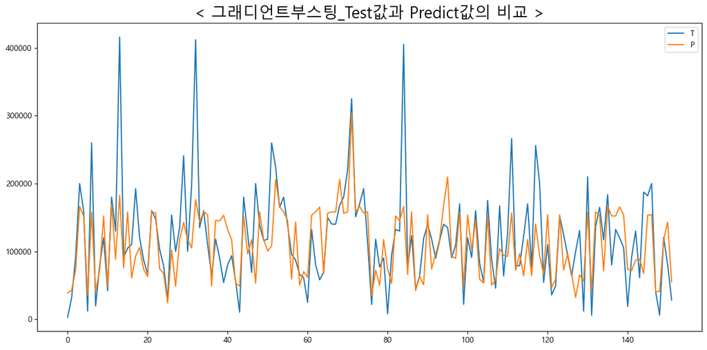

```python
plt.figure(figsize=(15,7))
plt.title('< 그래디언트부스팅_Test값과 Predict값의 비교 >', fontsize=20)
plt.plot(pred_df_g)
plt.legend('TP')
```

### [ 릿지/라쏘 <- 랜덤포레스트 ]

범주형 데이터는 릿지/라쏘를 쓸 경우 직선처럼 그려져서 효과는x

```python
from sklearn.linear_model import Ridge
model_rid = Ridge(alpha=0.01).fit(X_train, y_train)
print('훈  련 세트 : {:.2f}'.format(model_rid.score(X_train, y_train)))
print('테스트 세트 : {:.2f}'.format(model_rid.score(X_test, y_test)))
```

```
훈  련 세트 : 0.33
테스트 세트 : 0.19
```

```python
from sklearn.linear_model import Lasso
model_la = Ridge(alpha=0.02).fit(X_train, y_train)
print('훈  련 세트 : {:.2f}'.format(model_la.score(X_train, y_train)))
print('테스트 세트 : {:.2f}'.format(model_la.score(X_test, y_test)))
```

```
훈  련 세트 : 0.33
테스트 세트 : 0.19
```

### [ 히스트그래디언팅 ]

```python
from sklearn.ensemble import HistGradientBoostingRegressor
reg_h = HistGradientBoostingRegressor(loss='poisson', learning_rate=0.35, max_depth=8, max_iter=500)
reg_h.fit(X_train, y_train)
```

```
HistGradientBoostingRegressor(learning_rate=0.35, loss='poisson', max_depth=8,
                              max_iter=500)
```

### 교차검증 (CV)

```python
from sklearn.model_selection import cross_val_score, cross_validate # 각 활용처 알아보고 cross_val_predict,
result = cross_val_score(reg_h, X, y, cv=10)
```

```python
allResult = cross_validate(reg_h, X, y,
                           return_train_score=True,
                           cv=10)
```

```python
resultDF1 = pd.DataFrame(allResult)
resultDF1[['test_score', 'train_score']]
```

|  | test_score | train_score |
| --- | --- | --- |
| 0 | 0.168523 | 0.732392 |
| 1 | 0.191282 | 0.761651 |
| 2 | 0.182201 | 0.732302 |
| 3 | 0.424504 | 0.704621 |
| 4 | 0.148880 | 0.716614 |
| 5 | 0.170253 | 0.735654 |
| 6 | 0.338622 | 0.735993 |
| 7 | 0.537105 | 0.728218 |
| 8 | 0.382977 | 0.729378 |
| 9 | 0.088881 | 0.740433 |

### KFold

```python
# Splitter 객체 생성 - KFold()
from sklearn.model_selection import KFold

kSplitter = KFold(n_splits=10, shuffle=True)
```

```python
allResult1 = cross_validate(reg_h, X, y,
                           return_train_score=True,
                           return_estimator=True,
                           cv=kSplitter)

resultDF1 = pd.DataFrame(allResult1)
resultDF1[['test_score', 'train_score']]
```

|  | test_score | train_score |
| --- | --- | --- |
| 0 | 0.499119 | 0.734183 |
| 1 | 0.313769 | 0.726022 |
| 2 | 0.461839 | 0.725770 |
| 3 | 0.100863 | 0.736654 |
| 4 | 0.326902 | 0.706283 |
| 5 | 0.368028 | 0.745891 |
| 6 | 0.271256 | 0.730669 |
| 7 | -0.024596 | 0.737661 |
| 8 | 0.420161 | 0.726432 |
| 9 | 0.243467 | 0.743716 |

### 하이퍼파라미터 조절

### GridSearchCV

```python
parameters_h = {'learning_rate': [0.01,0.02,0.03,0.04],
                'max_iter'    : [100, 200, 300, 500],
                'max_depth'    : [4,6,8,10],
                 }
```

```python
grid_reg = GridSearchCV(estimator=reg_h, param_grid = parameters_h, cv = 2, n_jobs=-1)
grid_reg.fit(X_train, y_train)
```

```
GridSearchCV(cv=2,
             estimator=HistGradientBoostingRegressor(learning_rate=0.35,
                                                     loss='poisson',
                                                     max_depth=8,
                                                     max_iter=500),
             n_jobs=-1,
             param_grid={'learning_rate': [0.01, 0.02, 0.03, 0.04],
                         'max_depth': [4, 6, 8, 10],
                         'max_iter': [100, 200, 300, 500]})
```

```python
print(" Result " )
print("\n [Best estimator] :\n",grid_reg.best_estimator_)
print("\n [Best score] :\n",grid_reg.best_score_)
print("\n [Best parameters] :\n",grid_reg.best_params_)
```

```
 Result

 [Best estimator] :
 HistGradientBoostingRegressor(learning_rate=0.04, loss='poisson', max_depth=4,
                              max_iter=200)

 [Best score] :
 0.3899596771511742

 [Best parameters] :
 {'learning_rate': 0.04, 'max_depth': 4, 'max_iter': 200}
```

### 모델 평가

```python
print("훈  련 세트 : {:.3f}".format(reg_h.score(X_train, y_train)))
print("테스트 세트 : {:.3f}".format(reg_h.score(X_test, y_test)))
print('\n(파라미터 변경전 : )\n훈  련 세트 : 0.633\n테스트 세트 : 0.384')
```

```
훈  련 세트 : 0.728
테스트 세트 : 0.257

(파라미터 변경전 : )
훈  련 세트 : 0.633
테스트 세트 : 0.384
```

### 예측값과 실제값 비교

```python
predicted_h = reg_h.predict(X_test)
predicted_h = predicted_h.tolist()
```

```python
pred_df_h = pd.DataFrame({ 'test값':y_test, 'predict값':predicted_h })
```

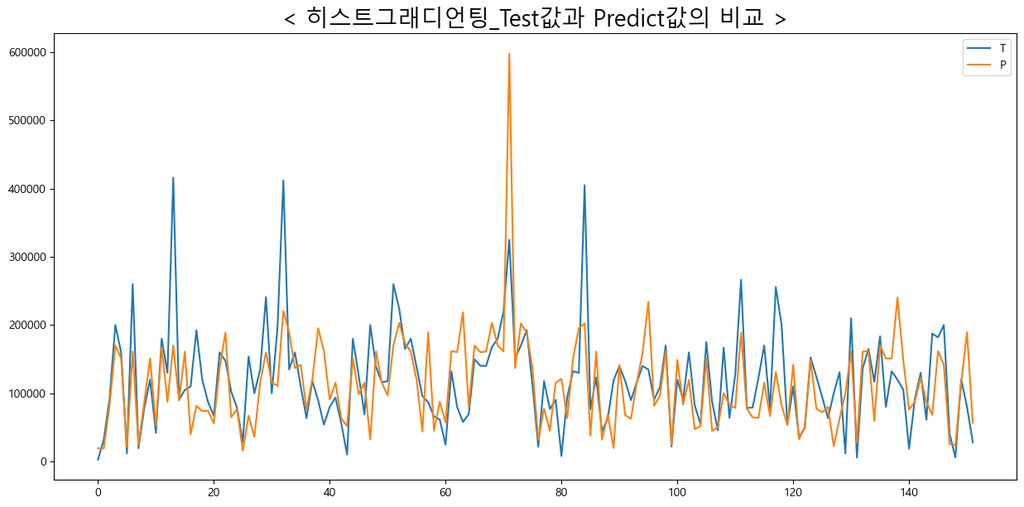

```python
plt.figure(figsize=(15,7))
plt.title('< 히스트그래디언팅_Test값과 Predict값의 비교 >', fontsize=20)
plt.plot(pred_df_h)
plt.legend('TP')
```

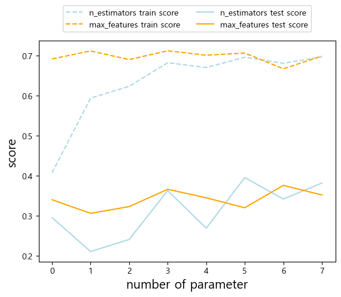

```
   => 그래프를 통해, parameter의 갯수가 적을 때보다 많을때가 성능이 더 좋아보임.
```

```python
# 파라미터 개수에 따른 score 변화 살피기

n_feature = X.shape[1]  # X.shape[1] = 8

score_n_tr_est = []
score_n_te_est = []
score_m_tr_mft = []
score_m_te_mft = []

for i in np.arange(1, n_feature+1): # n_estimators와 mat_features는 모두 0보다 큰 정수여야 하므로 1부터 시작
    params_n = {'n_estimators':i, 'max_features':'auto', 'n_jobs':-1} # **kwargs parameter
    params_m = {'n_estimators':10, 'max_features':i, 'n_jobs':-1}

    forest_n = RandomForestRegressor(**params_n).fit(X_train, y_train)
    forest_m = RandomForestRegressor(**params_m).fit(X_train, y_train)

    score_n_tr = forest_n.score(X_train, y_train)
    score_n_te = forest_n.score(X_test, y_test)
    score_m_tr = forest_m.score(X_train, y_train)
    score_m_te = forest_m.score(X_test, y_test)

    score_n_tr_est.append(score_n_tr)
    score_n_te_est.append(score_n_te)
    score_m_tr_mft.append(score_m_tr)
    score_m_te_mft.append(score_m_te)

index = np.arange(len(score_n_tr_est))
plt.plot(index, score_n_tr_est, label='n_estimators train score', color='lightblue', ls='--') # ls: linestyle
plt.plot(index, score_m_tr_mft, label='max_features train score', color='orange', ls='--')
plt.plot(index, score_n_te_est, label='n_estimators test score', color='lightblue')
plt.plot(index, score_m_te_mft, label='max_features test score', color='orange')
plt.legend(loc='center', bbox_to_anchor=(0.5, 1.1),
           ncol=2, fancybox=True, shadow=False) # fancybox: 박스모양, shadow: 그림자
plt.xlabel('number of parameter', size=15)
plt.ylabel('score', size=15)
plt.show()
print('   => 그래프를 통해, parameter의 갯수가 적을 때보다 많을때가 성능이 더 좋아보임.')
```